# capstone_project

## Predicting Stock Price Movement Using Machine Learning

### Problem Statement

Analyzing and predicting stock price movement have been a challenging but intriguing task for many analysts and researchers. A model that effectively predicts the direction of future stock price movement will aid investors and traders in making more profitable investments and being better at managing the risks of their portfolios.

### Project Overview

In this project, several machine learning models, including Random Forest, Gate Recurrent Unit(GRU) and Long Short Term Memory neuro network (LSTM), were adopted to build a classification model that predicts the direction of stock price movement(up or down). The model results were evaluated against the benchmark, Naive Method, using the accuracy metric. This notebook includes the following sections:

- Data Import
- Exploritory Data Analysis and Feature Engineering
- Data Preprocessing
- Machine Learning and Model Evaluation
- Results and Conclusion

### Intallations

- This Notebook was run on Macbook pro 13 with Apple M1 chip
- All packages listed below are compatible with Mac M1 and have been installed locally

```python
# Import relevant packages

import pandas as pd
import pandas_ta as ta
import numpy as np
from yahoofinancials import YahooFinancials
import matplotlib.pyplot as plt
import seaborn as sns
from statsmodels.graphics.tsaplots import plot_pacf
from statsmodels.tsa.stattools import adfuller

from sklearn.preprocessing import StandardScaler
from sklearn.model_selection import ParameterGrid
from sklearn.ensemble import RandomForestClassifier
from sklearn.metrics import accuracy_score

#import keras.losses
from keras.models import Sequential
from keras.layers import GRU, LSTM, Dropout, Dense

from numpy.random import seed
seed(42)

import warnings
warnings.filterwarnings('ignore')
```

## Data Import

The stock price data used in this project is retrieved from [Yahoo! Finance](https://finance.yahoo.com/) via yahoofinancials API. The data consists of trading date(date), opening price(open), highest and lowest price traded in the day(high/low), closing price adjusted for stock splits(close), closing price adjusted for splits and dividends(adjclose), and finally the trading volume(volume). Past 10 years' data of 10 well-known US stocks were used for exploratory data analysis and machine learning.

```python
# Stock list and data range used for model training/testing
stocks = ['AAPL', 'MSFT', 'INTC', 'AMZN', 'NVDA', 'QCOM', 'TSM', 'IBM', 'GOOGL', 'TSLA']
startDate = '2012-10-17'
endDate = '2022-10-17'
```

```python
# Define a functon to retrieve daily historical price data using yahoofinancials API
def getPriceData(symbols, startDate, endDate):
    yf_symbols = YahooFinancials(symbols)
    daily_prices = yf_symbols.get_historical_price_data(startDate, endDate, 'daily')
    return daily_prices
```

```python
prices = getPriceData(stocks, startDate, endDate)
```

```python
# Create price dataframe for each symbol:
for s in stocks:
    globals()[f'df_{s}'] = pd.DataFrame(prices[s]['prices'])
    globals()[f'df_{s}']['symbol'] = s
    globals()[f'df_{s}'].rename(columns={'formatted_date':'date', 'date':'epoch'}, inplace=True)
    globals()[f'df_{s}'].drop(columns=['epoch'], inplace=True)
    globals()[f'df_{s}'].set_index('date', inplace=True)
```

```python
# Check how the dataframe looks like using AAPL as an example
df_AAPL.head()
```

| date | high | low | open | close | volume | adjclose | symbol |
| --- | --- | --- | --- | --- | --- | --- | --- |
| 2012-10-17 | 23.313929 | 23.000000 | 23.173929 | 23.021786 | 389037600 | 19.741129 | AAPL |
| 2012-10-18 | 22.930714 | 22.500000 | 22.842501 | 22.594286 | 476624400 | 19.374546 | AAPL |
| 2012-10-19 | 22.563213 | 21.772142 | 22.537500 | 21.780001 | 744086000 | 18.676304 | AAPL |
| 2012-10-22 | 22.692142 | 21.812857 | 21.872143 | 22.643929 | 546730800 | 19.417118 | AAPL |
| 2012-10-23 | 22.639286 | 21.846430 | 22.535713 | 21.905714 | 707145600 | 18.784103 | AAPL |

```python
df_AAPL.describe()
```

|  | high | low | open | close | volume | adjclose |
| --- | --- | --- | --- | --- | --- | --- |
| count | 2515.000000 | 2515.000000 | 2515.000000 | 2515.000000 | 2.515000e+03 | 2515.000000 |
| mean | 60.507266 | 59.193243 | 59.839145 | 59.873977 | 1.819999e+08 | 58.133704 |
| std | 48.188074 | 46.978416 | 47.572076 | 47.607639 | 1.426334e+08 | 48.193606 |
| min | 14.271429 | 13.753571 | 13.856071 | 13.947500 | 4.100000e+07 | 12.084597 |
| 25% | 26.461249 | 26.010000 | 26.207500 | 26.287500 | 9.432060e+07 | 24.048593 |
| 50% | 39.730000 | 39.000000 | 39.375000 | 39.302502 | 1.340544e+08 | 37.637562 |
| 75% | 79.653748 | 78.032501 | 78.792500 | 78.781250 | 2.143056e+08 | 77.661781 |
| max | 182.940002 | 179.119995 | 182.630005 | 182.009995 | 1.460852e+09 | 181.259933 |

## Exploritory Data Analysis and Feature Engineering

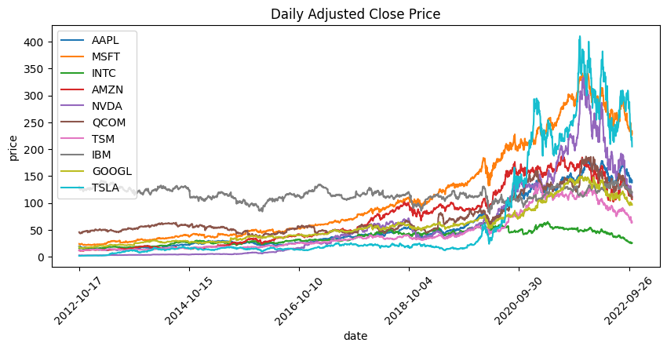

```python
# Plot the time series adjclose price data
plt.figure(figsize=(10,4))

for s in stocks:
    globals()[f'df_{s}']['adjclose'].plot(label=s, legend=True)

plt.xticks(rotation=45)
plt.ylabel('price')
plt.title('Daily Adjusted Close Price')
plt.show();
```

The daily adjusted close prices of most of the stocks show an upward trend over the last 10 years. Such data may not be suitable inputs for Machine Learning models that cannot handle non-stationary data well. In fact, it is more interesting to know whether the stock price will move up or down and by what percentage rather than look at the absolute price. Let's generate the daily return for all the selected stocks. Logarithmic return, which is commonly used in financial data modelling, is used in this project.

```python
# Define a function to generate the log return over a given period:
def genLogReturn(df, period=1):
    '''
    Parameters
    ----------
    df: dataframe
        An intput dataframe of stock price data
    period: int, default to 1
        The number of days over which the log return is calculated
    Returns
    ----------
    dataframe
        The input dataframe with daily log return and trend metrics concatenated
    '''
    df[f'{period}d_return'] = np.log(df['adjclose']) - np.log(df['adjclose'].shift(period))
    df[f'{period}d_future_return'] = df[f'{period}d_return'].shift(-period)

    # Storp Price Trend metrics: 1 for moving up, 0 for moving down
    df[f'{period}d_trend'] = [1 if df[f'{period}d_return'][i] > 0 else 0 for i in range(len(df))]
    df[f'{period}d_future_trend'] = [1 if df[f'{period}d_future_return'][i] > 0 else 0 for i in range(len(df))]
    return df
```

```python
# Generate log returns for all selected stocks
for s in stocks:
    globals()[f'df_{s}'] = genLogReturn(globals()[f'df_{s}'])
```

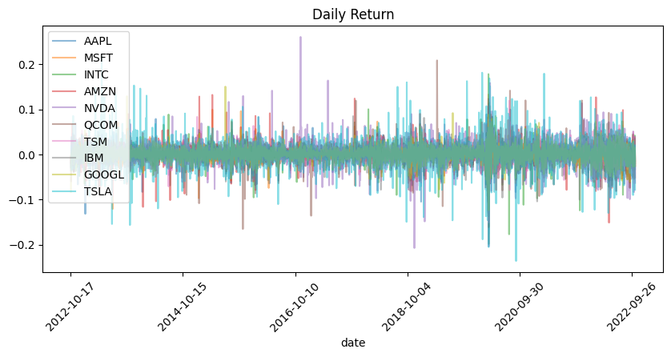

```python
# Plot the daily log return
plt.figure(figsize=(10,4))

for s in stocks:
    globals()[f'df_{s}']['1d_return'].plot(label=s, alpha=0.5, legend=True)

plt.xticks(rotation=45)
plt.title('Daily Return')
plt.legend(loc='upper left')
plt.show();
```

Glancing at above chart, I could not see an obvious trend for the returns of the selected stocks, unlike their prices'. Let's summarize the percentage of daily upward movement and downward movement for each stock over the last 10 years.

- up_pct: percentage of the number of days when the adjclose price is higher than the previous day's
- down_pct: percentage of the number of days when the adjclose price is lower than the previous day's

```python
df_trend = pd.DataFrame(index=['up_pct', 'down_pct'])
for s in stocks:
    up_pct = globals()[f'df_{s}']['1d_future_trend'].sum() * 100 / len(globals()[f'df_{s}'])
    df_trend[s] = pd.DataFrame([up_pct, 100 - up_pct], index=['up_pct', 'down_pct'])

print(df_trend)
```

```
               AAPL       MSFT       INTC       AMZN       NVDA       QCOM  \
up_pct    52.246521  52.962227  51.650099  53.439364  53.240557  52.047714
down_pct  47.753479  47.037773  48.349901  46.560636  46.759443  47.952286

                TSM        IBM      GOOGL       TSLA
up_pct    51.848907  51.133201  52.604374  52.326044
down_pct  48.151093  48.866799  47.395626  47.673956
```

It seems that the percentages of upward movement and downward movement are close to 50% for all stocks. Looks like we have a balanced dataset. Now let's take a further look at a specific stock.

```python
# Choosing AAPL for the subsequent analysis
symbol = 'AAPL'
df = df_AAPL.copy()
df.head()
```

| date | high | low | open | close | volume | adjclose | symbol | 1d_return | 1d_future_return | 1d_trend | 1d_future_trend |
| --- | --- | --- | --- | --- | --- | --- | --- | --- | --- | --- | --- |
| 2012-10-17 | 23.313929 | 23.000000 | 23.173929 | 23.021786 | 389037600 | 19.741129 | AAPL | NaN | -0.018744 | 0 | 0 |
| 2012-10-18 | 22.930714 | 22.500000 | 22.842501 | 22.594286 | 476624400 | 19.374546 | AAPL | -0.018744 | -0.036705 | 0 | 0 |
| 2012-10-19 | 22.563213 | 21.772142 | 22.537500 | 21.780001 | 744086000 | 18.676304 | AAPL | -0.036705 | 0.038900 | 0 | 1 |
| 2012-10-22 | 22.692142 | 21.812857 | 21.872143 | 22.643929 | 546730800 | 19.417118 | AAPL | 0.038900 | -0.033144 | 1 | 0 |
| 2012-10-23 | 22.639286 | 21.846430 | 22.535713 | 21.905714 | 707145600 | 18.784103 | AAPL | -0.033144 | 0.005641 | 0 | 1 |

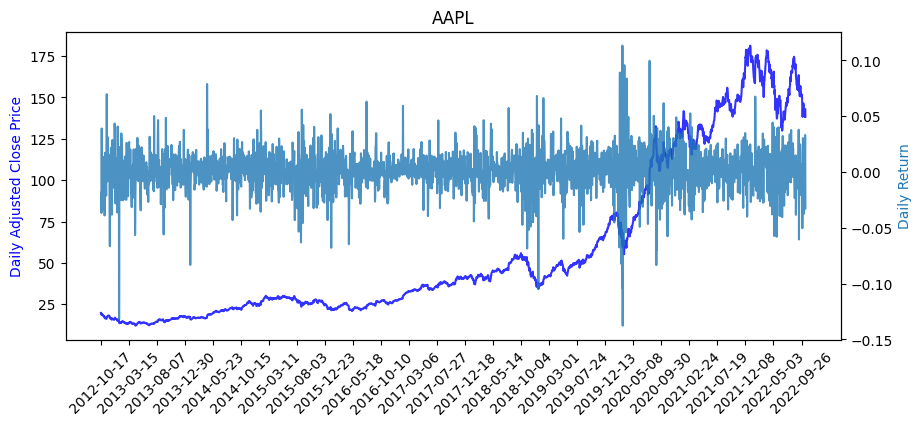

```python
# Plot the daily turen and daily adjclose price for the selected symbol
fig, ax1 = plt.subplots(figsize=(10,4))
ax2 = ax1.twinx()
ax1.plot(df['adjclose'], 'b-', alpha=0.8)
ax2.plot(df['1d_return'], 'tab:blue', alpha=0.8)

ax1.set_xticks(ax1.get_xticks()[::100])
ax1.set_xticklabels(labels=ax1.get_xticklabels(), rotation=45)
ax1.set_ylabel('Daily Adjusted Close Price', color='b')
ax2.set_ylabel('Daily Return', color='tab:blue')
plt.title(symbol)
plt.show();
```

```python
df['1d_return'].describe()
```

```
count    2514.000000
mean        0.000775
std         0.018294
min        -0.137708
25%        -0.007549
50%         0.000752
75%         0.010294
max         0.113158
Name: 1d_return, dtype: float64
```

The mean daily return is around 0%. However, this doesn't mean that the selected stock is not profitable. The stock price has been trending up, with cumulated return being positive. Let's also have a look at the distribution of the daily return.

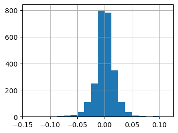

```python
plt.figure(figsize=(4,3))
df['1d_return'].hist(bins=20)
plt.show();
```

The daily return appears to be roughly normally distributed with a slightly longer left tail.

As we're dealing with time series data, let's now look at if the daily stock return exhibits any [autocorrelation](https://machinelearningmastery.com/gentle-introduction-autocorrelation-partial-autocorrelation/).

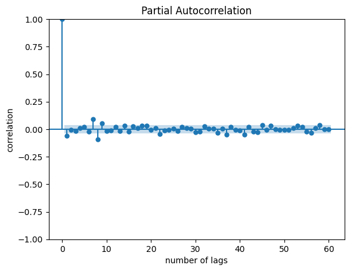

```python
plt.figure(figsize=(4,3))
plot_pacf(df['1d_return'][1:], lags=60) # excluding the first day which has NAN value and can't be handled by plot_pacf
plt.xlabel('number of lags')            # number of days prior to the current observation
plt.ylabel('correlation')
plt.show();
```

No strong autocorrelation can be observed for the daily return time series data for the selected symbol. In later part of this Notebook, I will examine if Machine Learning can uncover any hidden patterns in this dataset.

For completeness, I will also examine if the return data is stationary by conducting the [ADF test](https://en.wikipedia.org/wiki/Augmented_Dickey%E2%80%93Fuller_test).

```python
adf, pVal, numLag, numObs, critVals, icBest = adfuller(df['1d_return'][1:].values)
print('ADF test statistic:', adf)
print('ADF p-values:', pVal)
print('ADF number of lags used:', numLag)
print('ADF number of observations:', numObs)
print('ADF critical values:', critVals)
print('ADF best information criterion:', icBest)
```

```
ADF test statistic: -16.14125738603143
ADF p-values: 4.6733863159220097e-29
ADF number of lags used: 8
ADF number of observations: 2505
ADF critical values: {'1%': -3.4329631791044304, '5%': -2.8626944896608433, '10%': -2.5673845793841457}
ADF best information criterion: -12906.668916162917
```

The small p-value indicates that the alternative hypothesis is true and the daily return data is stationary, suitable as inputs for machine learning models.

### Creating More Features

This section generates some [technical indicators](https://www.investopedia.com/terms/t/technicalindicator.asp#:~:text=What%20Is%20a%20Technical%20Indicator,to%20predict%20future%20price%20movements) as additional features for the dataset. To satisfy stationarity, features in price terms are normalized against the adjclose price.

```python
# Time window in days for calculating various metrics
periods = [7, 14, 28, 60]
```

```python
# Define a function to create technical indicators as additional features
def genTechIndicators(df, periods):
    '''
    Parameters
    ----------
    df: dataframe
        An intput dataframe of stock price data
    periods: list
        A list of numbers in days over which the technical indicators will be calculated
    Return
    ----------
    dataframe
        The input dataframe with various technical indicators concatinated
    '''
    # create technical indicators for each period:
    for n in periods:
        # Exponentially Weighted Moving Average divided by adjclose
        df[str(n) + 'd_ma'] = ta.ema(df['adjclose'], length=n) / df['adjclose']

        # Relative Strength Index (RSI)
        df[str(n) + 'd_rsi'] = ta.rsi(df['adjclose'], length=n)

    # MACD and Signal Line divided by adjclose
    df['macd'] = ta.macd(df['adjclose'])['MACD_12_26_9'] / df['adjclose']
    df['signal'] = ta.macd(df['adjclose'])['MACDs_12_26_9'] / df['adjclose']

    return df
```

```python
df = genTechIndicators(df, periods)
```

```python
df.describe()
```

|  | high | low | open | close | volume | adjclose | 1d_return | 1d_future_return | 1d_trend | 1d_future_trend | 7d_ma | 7d_rsi | 14d_ma | 14d_rsi | 28d_ma | 28d_rsi | 60d_ma | 60d_rsi | macd | signal |
| --- | --- | --- | --- | --- | --- | --- | --- | --- | --- | --- | --- | --- | --- | --- | --- | --- | --- | --- | --- | --- |
| count | 2515.000000 | 2515.000000 | 2515.000000 | 2515.000000 | 2.515000e+03 | 2515.000000 | 2514.000000 | 2514.000000 | 2515.000000 | 2515.000000 | 2509.000000 | 2508.000000 | 2502.000000 | 2501.000000 | 2488.000000 | 2487.000000 | 2456.000000 | 2455.000000 | 2490.000000 | 2482.000000 |
| mean | 60.507266 | 59.193243 | 59.839145 | 59.873977 | 1.819999e+08 | 58.133704 | 0.000775 | 0.000775 | 0.522465 | 0.522465 | 0.998083 | 55.428467 | 0.995740 | 55.188006 | 0.990709 | 54.779827 | 0.978767 | 54.299798 | 0.004778 | 0.004835 |
| std | 48.188074 | 46.978416 | 47.572076 | 47.607639 | 1.426334e+08 | 48.193606 | 0.018294 | 0.018294 | 0.499594 | 0.499594 | 0.019967 | 18.039247 | 0.030749 | 13.230978 | 0.045015 | 9.587670 | 0.065713 | 6.764082 | 0.020105 | 0.018946 |
| min | 14.271429 | 13.753571 | 13.856071 | 13.947500 | 4.100000e+07 | 12.084597 | -0.137708 | -0.137708 | 0.000000 | 0.000000 | 0.920887 | 7.771995 | 0.900087 | 17.256255 | 0.860408 | 30.331203 | 0.778868 | 34.800001 | -0.082882 | -0.063917 |
| 25% | 26.461249 | 26.010000 | 26.207500 | 26.287500 | 9.432060e+07 | 24.048593 | -0.007549 | -0.007549 | 0.000000 | 0.000000 | 0.985598 | 41.648961 | 0.975332 | 45.236784 | 0.960696 | 47.970531 | 0.935164 | 49.875508 | -0.006140 | -0.004928 |
| 50% | 39.730000 | 39.000000 | 39.375000 | 39.302502 | 1.340544e+08 | 37.637562 | 0.000752 | 0.000752 | 1.000000 | 1.000000 | 0.996308 | 55.701978 | 0.992457 | 55.325295 | 0.984075 | 54.636962 | 0.968011 | 54.712607 | 0.007512 | 0.007277 |
| 75% | 79.653748 | 78.032501 | 78.792500 | 78.781250 | 2.143056e+08 | 77.661781 | 0.010294 | 0.010294 | 1.000000 | 1.000000 | 1.008399 | 69.799551 | 1.012234 | 64.668079 | 1.014624 | 61.255222 | 1.010273 | 58.405686 | 0.018721 | 0.017480 |
| max | 182.940002 | 179.119995 | 182.630005 | 182.009995 | 1.460852e+09 | 181.259933 | 0.113158 | 0.113158 | 1.000000 | 1.000000 | 1.106086 | 94.512778 | 1.147985 | 90.695463 | 1.221041 | 83.038213 | 1.275541 | 72.062509 | 0.057422 | 0.056904 |

```python
# Define a function to plot the additional features
def plotTechIndicators(df, periods):
    # MA
    plt.figure(figsize=(10,4))
    for p in periods:
        df[f'{p}d_ma'].plot()
    plt.legend(loc = 'upper left')
    plt.title('N-day Moving Average Normalized by Adjusted Close Price')
    plt.show();

    # RSI
    plt.figure(figsize=(10,4))
    for p in periods:
        df[f'{p}d_rsi'].plot()
    plt.axhline(0, linestyle='--', alpha=0.5, color = 'black')
    plt.axhline(20, linestyle='--', alpha=0.5, color = 'green')
    plt.axhline(30, linestyle='--', alpha=0.5, color = 'blue')
    plt.axhline(70, linestyle='--', alpha=0.5, color = 'blue')
    plt.axhline(80, linestyle='--', alpha=0.5, color = 'green')
    plt.axhline(100, linestyle='--', alpha=0.5, color = 'black')
    plt.legend(loc = 'upper left')
    plt.title('N-day RSI')
    plt.show();

    # MACD and Signal Line
    plt.figure(figsize=(10,4))
    df['macd'].plot()
    df['signal'].plot()
    plt.legend(loc = 'upper left')
    plt.title('MACD and Signal Line Normalized by Adjusted Close Price')
    plt.show();
```

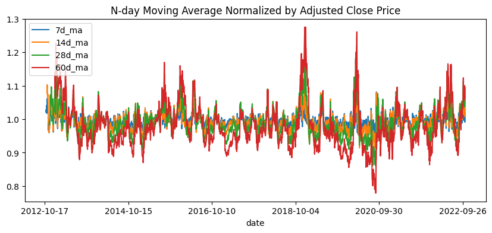

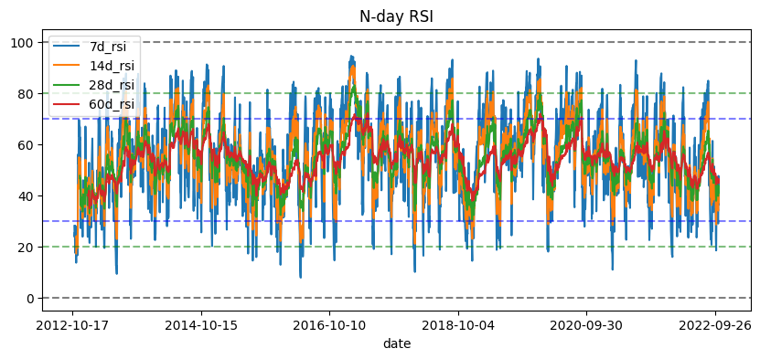

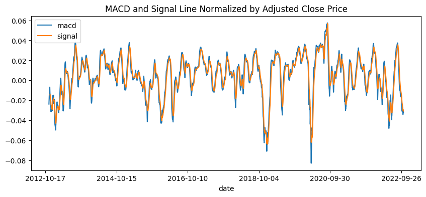

```python
plotTechIndicators(df, periods)
```

```python
# Plot the correlation within the datasets
def plotCorr(corr):
    plt.figure(figsize=(10,10))
    sns.heatmap(corr, annot=True, annot_kws = {"size": 8})
    plt.yticks(rotation=0, size = 14); plt.xticks(rotation=90, size = 14)
    plt.tight_layout()  # fits plot area to the plot, "tightly"
    plt.show();
```

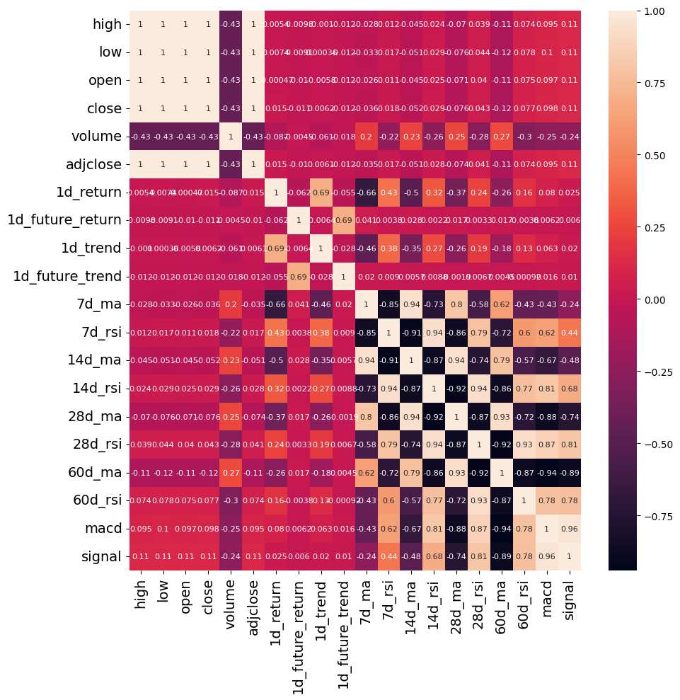

```python
plotCorr(df.corr())
```

### Define Feature Names and Target Name

In this project, two sets of features will be examined depending on individual model's requirements. As a Random Forest model requires 2-Dimentional inputs, in order to use time series/sequence data for prediciton, the number of features has to be one so that the sequence data in each training sample can be reshaped into 2D and be used as a valid input to the RF model. Recurrent Neural Networks(RNN) take 3-Dimentional inputs, and thus can use multiple features for training.

As high, low, open, close and adjclose are highly correlated and all show an upward trend, they will not be used as features.

The first feature set only contains the 1d_return data, to be used for single/multiple-timestep RF and RNN models.

The second feature set includes 1d_return, volume and all technical indicators created above, to be used for single-timestep RF and RNN models.

The target for prediction is the direction of stock price movement for the next day, i.e. the 1d_future_trend.

```python
feature_names_1 = ['1d_return']
feature_names_2 = feature_names_1 + ['volume'] + [f'{n}d_ma' for n in periods] + [f'{n}d_rsi' for n in periods] + ['macd', 'signal']

target_name = ['1d_future_trend']
```

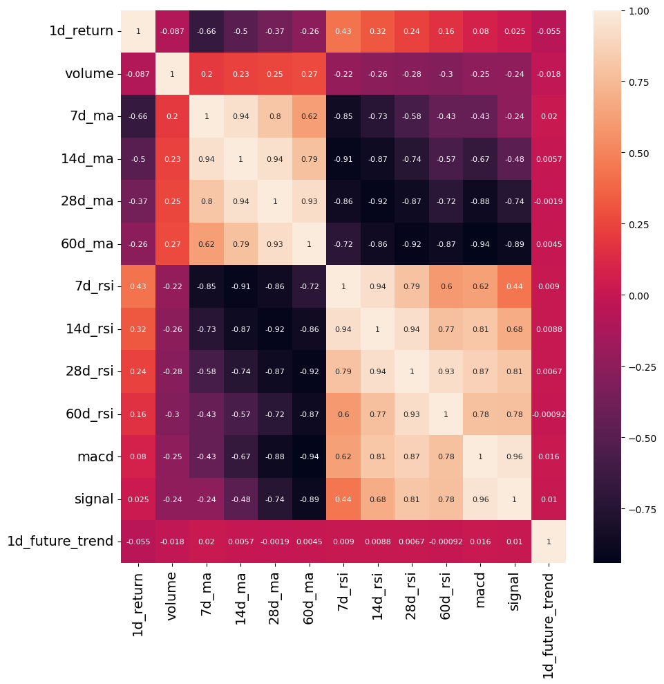

```python
plotCorr(df[feature_names_2 + target_name].corr())
```

## Data Preprocessing for Machine Learning

This section prepares the unscaled train/test datasets. The scaling of the data will be done in the subsequent RNN section.

```python
# Define a function to prepare training and testing datasets
def dataPrep(df, feature_names, target_name, split_pct=0.8):
    '''
    Parameteres
    ----------
    df: dataframe
        Input dataframe to be split into train/test features/target
    feature_names: list
        feature names
    target_name: list
        target name
    split_pct: float, default to 0.8
        ratio to split train/test data
    Return
    ----------
    dataframe, dataframe, dataframe, dataframe
        train_features, train_targets, test_features, test_targets
    '''
    # Drop NA values
    df = df.dropna()

    # Create features and targets
    features = df[feature_names]
    targets = df[target_name]

    # Create train, test splits
    train_size = int(df.shape[0] * split_pct)

    # Exclude the last day in the training dataset as its '1d_future_trend' is unkown within the training dataset itself
    train_features = features[:train_size-1]
    train_targets = targets[:train_size-1]

    test_features = features[train_size:]
    test_targets = targets[train_size:]

    print(f'Train size: {train_features.shape}\nTest size: {test_features.shape}')
    return train_features, train_targets, test_features, test_targets
```

```python
unscaled_x_train_1, y_train, unscaled_x_test_1, y_test = dataPrep(df, feature_names_1, target_name)
unscaled_x_train_2, y_train, unscaled_x_test_2, y_test = dataPrep(df, feature_names_2, target_name)
```

```
Train size: (1962, 1)
Test size: (491, 1)
Train size: (1962, 12)
Test size: (491, 12)
```

Now we have the data for Machine Learning!

## Naive Method -- The Benchmark

Predition using Naive Method is symply the direction of price movement of the last day. Let's calculate the one-step/1-day ahead prediction accuracy of the Naive Method that will be used as the benchmark in this project.

```python
# This dataframe will be used to track the accuracy metrics of various models
df_accuracy = pd.DataFrame(index=['train', 'test'])

# exclude the first day whose target is NAN under Naive Method
naive_accuracy_train = accuracy_score(y_train[1:], y_train.shift(1)[1:])
naive_accuracy_test = accuracy_score(y_test[1:],  y_test.shift(1)[1:])

df_accuracy['naive'] = pd.Series([naive_accuracy_train, naive_accuracy_test], index=['train', 'test'])
print(df_accuracy)
```

```
          naive
train  0.486996
test   0.500000
```

The Naive Method has a prediction accuracy of around 50%, which is sort of expeced for a random guess. Let's see how Naive Method performs for a 2-day ahead prediction:

```python
df_accuracy_2d = pd.DataFrame(index=['train', 'test'])
naive_accuracy_train_2d = accuracy_score(y_train[2:], y_train.shift(2)[2:])
naive_accuracy_test_2d = accuracy_score(y_test[2:],  y_test.shift(2)[2:])
df_accuracy_2d['naive'] = pd.Series([naive_accuracy_train_2d, naive_accuracy_test_2d], index=['train', 'test'])
print(df_accuracy_2d)
```

```
          naive
train  0.502551
test   0.486708
```

A similar predicition accuracy around 50%! In the following sections, several machine learning models will be examined with more focus on the one-step/1-day ahead prediction accuracy.

## Random Forest Classifier

As Random Forest is based on partitioning data to make predictions, it does not require normalization. Let's first build a simple Random Forest model that does not look at past sequence data.

```python
# Build and fit a Random Forest model with 1 feature
rfr = RandomForestClassifier(max_depth=5)
rfr.fit(unscaled_x_train_1, y_train)
```

```
RandomForestClassifier(max_depth=5)
```

```python
# Define a generic function that can run the prediction and calculate model eval metrics
def getModelResults(model, eval_metric, x_train, y_train, x_test, y_test, v=False):
    '''
    Parameters
    ----------
    model: model
        a fitted machine learning model
    eval_metric: str
        name of model evaluation metric
    x_train, y_train, x_test, y_test: dataframe/ndarray
        train_features, train_targets, test_features, test_targets
    v: bool, default to False
        verbose mode for printing extra info about train/test prediction results
    Return
    ----------
    ndarray, ndarray, flat, float
        train_preds, test_preds, metric_train, metric_test
    '''
    train_preds = model.predict(x_train)
    test_preds = model.predict(x_test)

    if v == True:
        print(train_preds.shape, test_preds.shape)

    if eval_metric == 'accuracy':
        metric_train = accuracy_score(y_train, train_preds)
        metric_test = accuracy_score(y_test, test_preds)
    else:
        print('Unsupported eval metric.')

    return train_preds, test_preds, metric_train, metric_test
```

```python
rfr_train_preds, rfr_test_preds, rfr_accuracy_train, rfr_accuracy_test = getModelResults(rfr, 'accuracy', unscaled_x_train_1, y_train, unscaled_x_test_1, y_test)

df_accuracy['rfr'] = pd.Series([rfr_accuracy_train, rfr_accuracy_test], index=['train', 'test'])
print(df_accuracy)
```

```
          naive       rfr
train  0.486996  0.619776
test   0.500000  0.494908
```

The Random Forest model trained using a single feature has higher train accuracy, but comparable test accuracy. Let's now use more features.

```python
# Build and fit a Random Forest model with multiple features
rfr = RandomForestClassifier(max_depth=5)
rfr.fit(unscaled_x_train_2, y_train)
```

```
RandomForestClassifier(max_depth=5)
```

```python
rfr_train_preds, rfr_test_preds, rfr_accuracy_train, rfr_accuracy_test = getModelResults(rfr, 'accuracy', unscaled_x_train_2, y_train, unscaled_x_test_2, y_test)

df_accuracy['rfr_mf'] = pd.Series([rfr_accuracy_train, rfr_accuracy_test], index=['train', 'test'])
print(df_accuracy)
```

```
          naive       rfr    rfr_mf
train  0.486996  0.619776  0.672783
test   0.500000  0.494908  0.507128
```

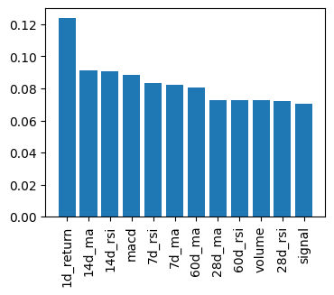

```python
# Get feature importances from the random forest model
importances = rfr.feature_importances_

# Get the index of importances from greatest importance to least
sorted_index = np.argsort(importances)[::-1]
x = range(len(importances))

# Create tick labels
labels = np.array(feature_names_2)[sorted_index]
plt.figure(figsize=(4, 3))
plt.bar(x, importances[sorted_index], tick_label=labels)

# Rotate tick labels to vertical
plt.xticks(rotation=90)
plt.show();
```

Adding more features for a RF model of max_depth 5 does not significantly improve the test accuracy. Now let's explore whether hyperparameters can be optimized for improved model performance.

## Random Forest Hyperparameter Tuning

Initial hyperparameter ranges tried:

- n_estimators: list(range(100,501,100))
- max_depth: list(range(5,31,5))
- min_samples_splits: list(range(2,7,1))
- min_samples_leaf: list(range(1,4,1))
- max_features: ['sqrt', 'log2', None],
- criterion: ['gini', 'entropy', 'log_loss']
- bootstrap: [True, False]

Observations:

- Increasing the number of estimators, min_sample_splits and min_samples_leaf did not significantly improve model performance.
- Larger max_depth tends to overfit -- giving high accuracy for the training dataset but low accuracy for test dataset. Training accuracy reached > 90% with 9+ max depths, while test accuracy stayed between 48% to 54%.
- No restriction on max_features yielded slightly higher accuracy than with restriction. Max_features was removed from hyperparameter tuning below as its default setting is None.
- Gini is used as the criterion for training since it slightly outperformed the other two.
- Bootstrap performed better than no boostrap. Bootstrap is not included in the hyperparameters dict below as its default setting is True.

After a few iterations, below hyperparameter ranges are chosen to demonstrate hyperparameter tuning.

```python
# Create a dictionary of hyperparameters to search
grid = {'n_estimators': list(range(100,201,100)),
        'max_depth': list(range(3,16,3)),
        'criterion': ['gini'],
        'bootstrap': [True],
        'random_state': [42]}
```

```python
# Loop through the parameter grid, set the hyperparameters, and save the scores
test_scores = []
for g in ParameterGrid(grid):
    rfr.set_params(**g)  # ** is "unpacking" the dictionary
    rfr.fit(unscaled_x_train_2, y_train)
    train_preds, test_preds, accuracy_train, accuracy_test = getModelResults(rfr, 'accuracy', unscaled_x_train_2, y_train, unscaled_x_test_2, y_test)
    test_scores.append(accuracy_test)
    print(f'Hyperparameters: {g}...')
    print(f'Train Accuracy: {accuracy_train}. Test Accuracy: {accuracy_test}')

# Find best hyperparameters from the test score and print
best_idx = np.argmax(test_scores)
best_hypo = ParameterGrid(grid)[best_idx]
print (f'Best Test Accuracy: {test_scores[best_idx]}. Acurracy Range: [{min(test_scores)}, {max(test_scores)}].')
print (f'Best hyperparameters: {best_hypo}')
```

```
Hyperparameters: {'bootstrap': True, 'criterion': 'gini', 'max_depth': 3, 'n_estimators': 100, 'random_state': 42}...
Train Accuracy: 0.5790010193679919. Test Accuracy: 0.5356415478615071
Hyperparameters: {'bootstrap': True, 'criterion': 'gini', 'max_depth': 3, 'n_estimators': 200, 'random_state': 42}...
Train Accuracy: 0.582059123343527. Test Accuracy: 0.5274949083503055
Hyperparameters: {'bootstrap': True, 'criterion': 'gini', 'max_depth': 6, 'n_estimators': 100, 'random_state': 42}...
Train Accuracy: 0.7507645259938838. Test Accuracy: 0.515274949083503
Hyperparameters: {'bootstrap': True, 'criterion': 'gini', 'max_depth': 6, 'n_estimators': 200, 'random_state': 42}...
Train Accuracy: 0.744138634046891. Test Accuracy: 0.5254582484725051
Hyperparameters: {'bootstrap': True, 'criterion': 'gini', 'max_depth': 9, 'n_estimators': 100, 'random_state': 42}...
Train Accuracy: 0.9118246687054027. Test Accuracy: 0.5356415478615071
Hyperparameters: {'bootstrap': True, 'criterion': 'gini', 'max_depth': 9, 'n_estimators': 200, 'random_state': 42}...
Train Accuracy: 0.9215086646279307. Test Accuracy: 0.5193482688391039
Hyperparameters: {'bootstrap': True, 'criterion': 'gini', 'max_depth': 12, 'n_estimators': 100, 'random_state': 42}...
Train Accuracy: 0.9898063200815495. Test Accuracy: 0.4969450101832994
Hyperparameters: {'bootstrap': True, 'criterion': 'gini', 'max_depth': 12, 'n_estimators': 200, 'random_state': 42}...
Train Accuracy: 0.9928644240570846. Test Accuracy: 0.515274949083503
Hyperparameters: {'bootstrap': True, 'criterion': 'gini', 'max_depth': 15, 'n_estimators': 100, 'random_state': 42}...
Train Accuracy: 1.0. Test Accuracy: 0.5112016293279023
Hyperparameters: {'bootstrap': True, 'criterion': 'gini', 'max_depth': 15, 'n_estimators': 200, 'random_state': 42}...
Train Accuracy: 1.0. Test Accuracy: 0.5193482688391039
Best Test Accuracy: 0.5356415478615071. Acurracy Range: [0.4969450101832994, 0.5356415478615071].
Best hyperparameters: {'random_state': 42, 'n_estimators': 100, 'max_depth': 3, 'criterion': 'gini', 'bootstrap': True}
```

```python
# Fit the best model
rfr.set_params(**best_hypo)
rfr.fit(unscaled_x_train_2, y_train)
rfr_train_preds, rfr_test_preds, rfr_accuracy_train, rfr_accuracy_test = getModelResults(rfr, 'accuracy', unscaled_x_train_2, y_train, unscaled_x_test_2, y_test)

df_accuracy['rfr_hypo'] = pd.Series([rfr_accuracy_train, rfr_accuracy_test], index=['train', 'test'])
print(df_accuracy)
```

```
          naive       rfr    rfr_mf  rfr_hypo
train  0.486996  0.619776  0.672783  0.579001
test   0.500000  0.494908  0.507128  0.535642
```

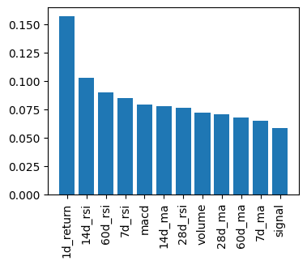

```python
# Get feature importances from the random forest model
importances = rfr.feature_importances_

# Get the index of importances from greatest importance to least
sorted_index = np.argsort(importances)[::-1]
x = range(len(importances))

# Create tick labels
labels = np.array(feature_names_2)[sorted_index]
plt.figure(figsize=(4, 3))
plt.bar(x, importances[sorted_index], tick_label=labels)

# Rotate tick labels to vertical
plt.xticks(rotation=90)
plt.show();
```

Test accuracy improved by around 3% with hyperparameter tuning, but stil not high. 1d_return's feature importance remains the highest and increases from 0.12 to 0.155 with hyperparameter tuning. 14d_rsi's feature importance ranks the second and imporves from 0.09 to 0.1.

## Random Forest with Past Sequence Data

Now let's look at using past sequences in a Random Forest classifer for prediction using 1d_return as the only feature, as discussed earlier. This feature will be reshaped into an array containing past n-day data.

```python
# Define a function to prepare train/test data with past sequence data
def sequenceDataPrepRfr(train_feature, train_target, test_feature, test_target, timestep):
    '''
    Parameters
    ----------
    train_feature/test_feature:
        '1d_return'
    train_target/test_target:
        '1d_day_future_return'
    timestep: int
        timesteps in days
    Return
    ----------
    ndarray, ndarray, ndarray, ndarray
        train_features, train_targets, test_features, test_targets
    '''
    # The n-timestep sequence data includes the data of the current day, as the prediction target is 1d_future_trend.
    x_train = np.array([train_feature[i-timestep:i] for i in range(timestep, len(train_feature)+1)])
    y_train = np.array([train_target.iloc[i-1] for i in range(timestep, len(train_feature)+1)])
    y_train = np.reshape(y_train, (y_train.shape[0], 1))
    x_test = np.array([test_feature[i-timestep:i] for i in range(timestep, len(test_feature)+1)])
    y_test = np.array([test_target.iloc[i-1] for i in range(timestep, len(test_feature)+1)])
    y_test = np.reshape(y_test, (y_test.shape[0], 1))

    return x_train, y_train, x_test, y_test
```

```python
# Loop through the parameter grid, set the hyperparameters, and save the scores
test_scores = []
timesteps = [14, 30, 60]

for p in timesteps:
    sq_x_train, sq_y_train, sq_x_test, sq_y_test = sequenceDataPrepRfr(unscaled_x_train_2['1d_return'], y_train, unscaled_x_test_2['1d_return'], y_test, p)
    rfr = RandomForestClassifier(**best_hypo)
    rfr.fit(sq_x_train, sq_y_train)
    rfr_train_preds, rfr_test_preds, rfr_accuracy_train, rfr_accuracy_test = getModelResults(rfr, 'accuracy', sq_x_train, sq_y_train, sq_x_test, sq_y_test)
    test_scores.append(rfr_accuracy_test)

# Find best perforing period from the test score and print
best_idx = np.argmax(test_scores)
best_timestep = timesteps[best_idx]
print (f'Best accuracy: {test_scores[best_idx]}')
print (f'Best time-window: {best_timestep}')
```

```
Best accuracy: 0.5216450216450217
Best time-window: 30
```

```python
# Fit the best model
sq_x_train, sq_y_train, sq_x_test, sq_y_test = sequenceDataPrepRfr(unscaled_x_train_2['1d_return'], y_train, unscaled_x_test_2['1d_return'], y_test, 30)
rfr.set_params(**best_hypo)
rfr.fit(sq_x_train, sq_y_train)
rfr_train_preds, rfr_test_preds, rfr_accuracy_train, rfr_accuracy_test = getModelResults(rfr, 'accuracy', sq_x_train, sq_y_train, sq_x_test, sq_y_test)

df_accuracy['rfr_recur'] = pd.Series([rfr_accuracy_train, rfr_accuracy_test], index=['train', 'test'])
print(df_accuracy)
```

```
          naive       rfr    rfr_mf  rfr_hypo  rfr_recur
train  0.486996  0.619776  0.672783  0.579001   0.604759
test   0.500000  0.494908  0.507128  0.535642   0.521645
```

With past sequence data of a single feature, the Random Forest model doesn't seem to generate superior result compared to the one using multiple features and with hyperparameters tuned. Let's also examine how a Random Forest model using past sequence data performs for 2-day ahead prediction.

```python
# Shifting target_value to the previous 1 day, effectively new target value is '2d_future_trend'
# Since the last day's 2d_future_trend is unknown, the last day is removed from the train/test dataset

x_train_rfr_2d = sq_x_train[:-1,:]
y_train_rfr_2d = sq_y_train[1:]
x_test_rfr_2d = sq_x_test[:-1,:]
y_test_rfr_2d = sq_y_test[1:]
```

```python
rfr.set_params(**best_hypo)
rfr.fit(x_train_rfr_2d, y_train_rfr_2d)
rfr_train_preds_2d, rfr_test_preds_2d, rfr_accuracy_train_2d, rfr_accuracy_test_2d = getModelResults(rfr, 'accuracy', x_train_rfr_2d, y_train_rfr_2d, x_test_rfr_2d, y_test_rfr_2d)
```

```python
# 2-day ahead prediction accuracy
df_accuracy_2d['rfr_recur'] = pd.Series([rfr_accuracy_train_2d, rfr_accuracy_test_2d], index=['train', 'test'])
print(df_accuracy_2d)

'''
Please note that the 2-day prediciton accuracy for the RF model is only added after the entire notebook is run.
The gru and lstm score will be explained in the later sections of this notebook.
'''
```

```
          naive       gru      lstm       rfr  rfr_recur
train  0.502551  0.523134  0.659306  0.600414   0.600414
test   0.486708  0.501200  0.515100  0.509761   0.509761
```

```
'\nPlease note that the 2-day prediciton accuracy for the RF model is only added after the entire notebook is run.\nThe gru and lstm score will be explained in the later sections of this notebook.\n'
```

Random Forest model's 2-day prediction test accuracy is comparable to the benchmark model's, althought the train accuracy is 10% higher. Let's now examine how models that work with both past sequence data and multiple features perform.

## Recurrent Neural Networks

A recurrent neural network (RNN) is a type of artificial neural network that deals with sequential data or time series data. In the following sections, two types of RNNs, namely GRU and LSTM, will be explored and examined. The training data fed into a RNN model needs to be in the shape of NxTxD, where:

- N is the number of samples
- T is the number of timesteps (in days in this project)
- D is the number of features

Besides, as the values of some of the features, such as 1d_return, are small, standardization will be applied for more efficient model training.

### RNN Data Preprocessing

```python
# Define a function to standardize the training and test data
def standardizeData(train_features, test_features, scaler=StandardScaler()):
    scaler.fit(train_features)
    scaled_train_features = scaler.transform(train_features)
    scaled_test_features = scaler.transform(test_features)
    return scaled_train_features, scaled_test_features
```

```python
# Standardize the data for the two sets of train/test features: single-feature '1d_return' and multiple features
scaled_x_train_1, scaled_x_test_1 = standardizeData(unscaled_x_train_1, unscaled_x_test_1)
scaled_x_train_2, scaled_x_test_2 = standardizeData(unscaled_x_train_2, unscaled_x_test_2)
```

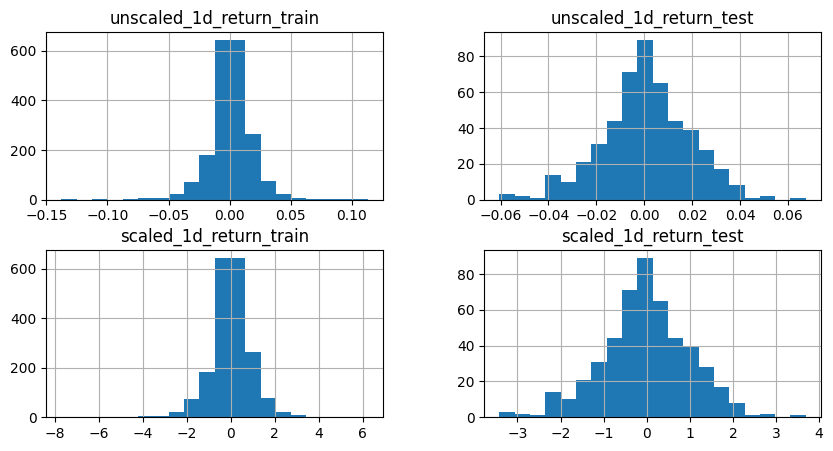

```python
# Plot the distributions of 1d_return train and test feature (scaled vs unscaled)
f, ax = plt.subplots(nrows=2, ncols=2, figsize=(10, 5))

unscaled_x_train_1.set_axis(['unscaled_1d_return_train'], axis=1).hist(ax=ax[0,0], bins=20)
pd.DataFrame(scaled_x_train_1, columns=['scaled_1d_return_train']).hist(ax=ax[1,0], bins=20)
unscaled_x_test_1.set_axis(['unscaled_1d_return_test'], axis=1).hist(ax=ax[0,1], bins=20)
pd.DataFrame(scaled_x_test_1, columns=['scaled_1d_return_test']).hist(ax=ax[1,1], bins=20)
plt.show();
```

```python
# Define a timestep variable to be used for data preprocessing, in number of days
timestep = 60
#timestep = 30
```

```python
# Define a function to prepare the features and targets data for a given timestep
def dataPrepRnn(train_features, train_target, test_features, test_target, timestep):
    x_train = []
    y_train = []
    x_test = []
    y_test = []

    # The n-timestep sequence data includes the data of the current day, as the prediction target is 1d_future_trend.
    x_train = np.array([train_features[i-timestep:i, :] for i in range(timestep, len(train_features)+1)])
    y_train = np.array([train_target.iloc[i-1] for i in range(timestep, len(train_target)+1)])
    x_test = np.array([test_features[i-timestep:i, :] for i in range(timestep, len(test_features)+1)])
    y_test = np.array([test_target.iloc[i-1] for i in range(timestep, len(test_target)+1)])

    return np.reshape(x_train, (-1, timestep, train_features.shape[1])), y_train, np.reshape(x_test, (-1, timestep, test_features.shape[1])), y_test
```

```python
# Run data processing for the two sets of feature/target data
x_train_rnn_1, y_train_rnn_1, x_test_rnn_1, y_test_rnn_1 = dataPrepRnn(scaled_x_train_1, y_train, scaled_x_test_1, y_test, timestep)
print(x_train_rnn_1.shape, y_train_rnn_1.shape, x_test_rnn_1.shape, y_test_rnn_1.shape)
```

```
(1903, 60, 1) (1903, 1) (432, 60, 1) (432, 1)
```

```python
x_train_rnn_2, y_train_rnn_2, x_test_rnn_2, y_test_rnn_2 = dataPrepRnn(scaled_x_train_2, y_train, scaled_x_test_2, y_test, timestep)
print(x_train_rnn_2.shape, y_train_rnn_2.shape, x_test_rnn_2.shape, y_test_rnn_2.shape)
```

```
(1903, 60, 12) (1903, 1) (432, 60, 12) (432, 1)
```

## Gated Recurrent Unit

Gated Recurrent Unit (GRU) is a type of RNN which is controlled by "gates" that determine the weights of the past and new information. Let's start with using 1 feature for model training.

```python
# Define a function to build a GRU Model
def buildGruModel(dataShape):
    '''
    Parameters
    ----------
    dataShape: list
        the shape parameter of the training input
    Return
    ----------
    GRU model
    '''
    N = dataShape[0]        # number of samples
    T = dataShape[1]        # timesteps
    D = dataShape[2]        # feature dimention
    K = 1                   # number of outputs

    model = Sequential()
    model.add(GRU(50, return_sequences=True, input_shape=(T, D)))
    model.add(Dropout(0.2))
    model.add(GRU(50, return_sequences=False))
    model.add(Dropout(0.2))
    model.add(Dense(K, activation='sigmoid' ))

    # Complie the model
    model.compile(optimizer='adam', loss='binary_crossentropy', metrics=['accuracy'])
    return model
```

```python
gru = buildGruModel(x_train_rnn_1.shape)
gru.summary()
```

```
Model: "sequential_2"
_________________________________________________________________
 Layer (type)                Output Shape              Param #
=================================================================
 gru_4 (GRU)                 (None, 60, 50)            7950

 dropout_4 (Dropout)         (None, 60, 50)            0

 gru_5 (GRU)                 (None, 50)                15300

 dropout_5 (Dropout)         (None, 50)                0

 dense_2 (Dense)             (None, 1)                 51

=================================================================
Total params: 23,301
Trainable params: 23,301
Non-trainable params: 0
_________________________________________________________________
```

```python
# Fit the model
history = gru.fit(x_train_rnn_1, y_train_rnn_1, batch_size=32, epochs=50)
```

```
2022-10-29 20:19:52.457492: I tensorflow/core/grappler/optimizers/custom_graph_optimizer_registry.cc:114] Plugin optimizer for device_type GPU is enabled.
2022-10-29 20:19:52.607589: I tensorflow/core/grappler/optimizers/custom_graph_optimizer_registry.cc:114] Plugin optimizer for device_type GPU is enabled.
2022-10-29 20:19:52.718570: I tensorflow/core/grappler/optimizers/custom_graph_optimizer_registry.cc:114] Plugin optimizer for device_type GPU is enabled.
2022-10-29 20:19:52.877165: I tensorflow/core/grappler/optimizers/custom_graph_optimizer_registry.cc:114] Plugin optimizer for device_type GPU is enabled.
```

```
2022-10-29 20:19:53.030577: I tensorflow/core/grappler/optimizers/custom_graph_optimizer_registry.cc:114] Plugin optimizer for device_type GPU is enabled.
```

```python
# Define a function to plot RNN training loss and accuracy
def plotRnnResults(history, title=None):
    fig, ax1 = plt.subplots(figsize=(4, 4))
    ax2 = ax1.twinx()
    ax1.plot(history.history['loss'], 'b-', alpha=0.8)
    ax2.plot(history.history['accuracy'], 'g', alpha=0.8)

    ax1.set_ylabel('loss', color='b')
    ax2.set_ylabel('accuracy', color='g')

    if title:
        plt.title(title)
    plt.show();
```

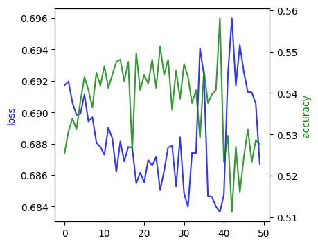

```python
plotRnnResults(history)
```

```python
gru.evaluate(x_test_rnn_1, y_test_rnn_1)
```

```
2022-10-29 20:23:23.206871: I tensorflow/core/grappler/optimizers/custom_graph_optimizer_registry.cc:114] Plugin optimizer for device_type GPU is enabled.
2022-10-29 20:23:23.263951: I tensorflow/core/grappler/optimizers/custom_graph_optimizer_registry.cc:114] Plugin optimizer for device_type GPU is enabled.
2022-10-29 20:23:23.367761: I tensorflow/core/grappler/optimizers/custom_graph_optimizer_registry.cc:114] Plugin optimizer for device_type GPU is enabled.
```

```
[0.7004124522209167, 0.5231481790542603]
```

```python
df_accuracy['gru'] = pd.Series([history.history['accuracy'][-1], 0.5231], index=['train', 'test'])
print(df_accuracy)
```

```
          naive       rfr    rfr_mf  rfr_hypo  rfr_recur       gru
train  0.486996  0.619776  0.672783  0.579001   0.604759  0.527588
test   0.500000  0.494908  0.507128  0.535642   0.521645  0.523100
```

The single-feature GRU doesn't seem to perform well as shown in the loss and accuracy metrics. Now let's add more features to the GRU model training.

## GRU with More Features

Hyperparameter turning has been done but not shown in this notebook, details are summarized in the project report. Parameters tuned include batch_size in [16, 32, 64] and epochs in [10, 20, 30, 40, 50, 100]. In view of the training and testing sample size, which are 1903 and 432 respectively, larger batch size was not used. Besides, the training and testing accuracy did not seem to improve much with epochs larger than 100. In below section, the best-performing hyperparameters tried are used for model training.

```python
gru = buildGruModel(x_train_rnn_2.shape)
gru.summary()
```

```
Model: "sequential_6"
_________________________________________________________________
 Layer (type)                Output Shape              Param #
=================================================================
 gru_12 (GRU)                (None, 60, 50)            9600

 dropout_12 (Dropout)        (None, 60, 50)            0

 gru_13 (GRU)                (None, 50)                15300

 dropout_13 (Dropout)        (None, 50)                0

 dense_6 (Dense)             (None, 1)                 51

=================================================================
Total params: 24,951
Trainable params: 24,951
Non-trainable params: 0
_________________________________________________________________
```

```python
# Fit the model
history = gru.fit(x_train_rnn_2, y_train_rnn_2, batch_size=16, epochs=40)
```

```
2022-10-29 20:44:53.970237: I tensorflow/core/grappler/optimizers/custom_graph_optimizer_registry.cc:114] Plugin optimizer for device_type GPU is enabled.
2022-10-29 20:44:54.128421: I tensorflow/core/grappler/optimizers/custom_graph_optimizer_registry.cc:114] Plugin optimizer for device_type GPU is enabled.
2022-10-29 20:44:54.250794: I tensorflow/core/grappler/optimizers/custom_graph_optimizer_registry.cc:114] Plugin optimizer for device_type GPU is enabled.
2022-10-29 20:44:54.414370: I tensorflow/core/grappler/optimizers/custom_graph_optimizer_registry.cc:114] Plugin optimizer for device_type GPU is enabled.
```

```
2022-10-29 20:44:54.579326: I tensorflow/core/grappler/optimizers/custom_graph_optimizer_registry.cc:114] Plugin optimizer for device_type GPU is enabled.
```

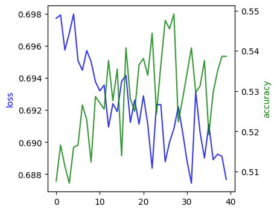

```python
plotRnnResults(history)
```

```python
gru.evaluate(x_test_rnn_2, y_test_rnn_2)
```

```
2022-10-29 20:52:28.474219: I tensorflow/core/grappler/optimizers/custom_graph_optimizer_registry.cc:114] Plugin optimizer for device_type GPU is enabled.
2022-10-29 20:52:28.529581: I tensorflow/core/grappler/optimizers/custom_graph_optimizer_registry.cc:114] Plugin optimizer for device_type GPU is enabled.
2022-10-29 20:52:28.648967: I tensorflow/core/grappler/optimizers/custom_graph_optimizer_registry.cc:114] Plugin optimizer for device_type GPU is enabled.
```

```
[0.6933104395866394, 0.5347222089767456]
```

```python
df_accuracy['gru_mf'] = pd.Series([history.history['accuracy'][-1], 0.5347], index=['train', 'test'])
print(df_accuracy)
```

```
          naive       rfr    rfr_mf  rfr_hypo  rfr_recur       gru    gru_mf
train  0.486996  0.619776  0.672783  0.579001   0.604759  0.527588  0.538623
test   0.500000  0.494908  0.507128  0.535642   0.521645  0.523100  0.534700
```

The one-step prediction using GRU is not outperforming RF with hyperparameter tuning. Let's also see how GRU performs for a 2-day ahead prediction.

```python
# Shifting target_value to the previous 1 day, effectively new target value is '2d_future_trend'
# Since the last day's 2d_future_trend is unknown, the last day is removed from the train/test dataset

x_train_rnn_3 = x_train_rnn_2[:-1,:,:]
y_train_rnn_3 = y_train_rnn_2[1:]
x_test_rnn_3 = x_test_rnn_2[:-1,:,:]
y_test_rnn_3 = y_test_rnn_2[1:]
```

```python
# Build and fit the model
gru = buildGruModel(x_train_rnn_3.shape)
history = gru.fit(x_train_rnn_3, y_train_rnn_3, batch_size=16, epochs=40)
```

```
2022-10-29 20:56:57.414584: I tensorflow/core/grappler/optimizers/custom_graph_optimizer_registry.cc:114] Plugin optimizer for device_type GPU is enabled.
2022-10-29 20:56:57.565582: I tensorflow/core/grappler/optimizers/custom_graph_optimizer_registry.cc:114] Plugin optimizer for device_type GPU is enabled.
2022-10-29 20:56:57.696356: I tensorflow/core/grappler/optimizers/custom_graph_optimizer_registry.cc:114] Plugin optimizer for device_type GPU is enabled.
2022-10-29 20:56:57.880451: I tensorflow/core/grappler/optimizers/custom_graph_optimizer_registry.cc:114] Plugin optimizer for device_type GPU is enabled.
```

```
2022-10-29 20:56:58.044769: I tensorflow/core/grappler/optimizers/custom_graph_optimizer_registry.cc:114] Plugin optimizer for device_type GPU is enabled.
```

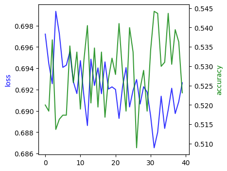

```python
plotRnnResults(history)
```

```python
gru.evaluate(x_test_rnn_3, y_test_rnn_3)
```

```
2022-10-29 21:00:26.906435: I tensorflow/core/grappler/optimizers/custom_graph_optimizer_registry.cc:114] Plugin optimizer for device_type GPU is enabled.
2022-10-29 21:00:26.965689: I tensorflow/core/grappler/optimizers/custom_graph_optimizer_registry.cc:114] Plugin optimizer for device_type GPU is enabled.
2022-10-29 21:00:27.081459: I tensorflow/core/grappler/optimizers/custom_graph_optimizer_registry.cc:114] Plugin optimizer for device_type GPU is enabled.
```

```
[0.7007308006286621, 0.5011601448059082]
```

```python
# 2-day ahead prediction accuracy
df_accuracy_2d['gru'] = pd.Series([history.history['accuracy'][-1], 0.5012], index=['train', 'test'])
print(df_accuracy_2d)
```

```
          naive       gru
train  0.502551  0.523134
test   0.486708  0.501200
```

2-day ahead prediction is around 2% higher for the trainig and test set. However, the prediction accuracy still do not seem to be significantly higher than 50% of a random walk.

## Long Short-Term Memory neural network (LSTM)

LSTM is another type of RNN model that has one additional gates compared to GRU. It is known to work well for longer sequences. Let's start with using 1 feature for model training.

```python
# Define a function to build a LSTM Model
def buildLstmModel(dataShape):
    '''
    Parameters
    ----------
    dataShape: list
        the shape parameter of the training input
    Return
    ----------
    LSTM model
    '''
    N = dataShape[0]        # number of samples
    T = dataShape[1]        # timesteps
    D = dataShape[2]        # feature dimention
    K = 1                   # number of output

    model = Sequential()
    model.add(LSTM(50, return_sequences=True, input_shape=(T, D)))
    #model.add(Dropout(0.2))
    model.add(LSTM(50, return_sequences=False))
    #model.add(Dropout(0.2))
    model.add(Dense(K, activation='sigmoid' ))

    # Complie the model
    model.compile(optimizer='adam', loss='binary_crossentropy', metrics=['accuracy'])
    return model
```

```python
lstm = buildLstmModel(x_train_rnn_1.shape)
lstm.summary()
```

```
Model: "sequential_9"
_________________________________________________________________
 Layer (type)                Output Shape              Param #
=================================================================
 lstm (LSTM)                 (None, 60, 50)            10400

 lstm_1 (LSTM)               (None, 50)                20200

 dense_9 (Dense)             (None, 1)                 51

=================================================================
Total params: 30,651
Trainable params: 30,651
Non-trainable params: 0
_________________________________________________________________
```

```python
# Fit the model
history = lstm.fit(x_train_rnn_1, y_train_rnn_1, batch_size=32, epochs=50)
```

```
2022-10-29 21:01:59.424618: I tensorflow/core/grappler/optimizers/custom_graph_optimizer_registry.cc:114] Plugin optimizer for device_type GPU is enabled.
2022-10-29 21:01:59.581135: I tensorflow/core/grappler/optimizers/custom_graph_optimizer_registry.cc:114] Plugin optimizer for device_type GPU is enabled.
2022-10-29 21:01:59.688984: I tensorflow/core/grappler/optimizers/custom_graph_optimizer_registry.cc:114] Plugin optimizer for device_type GPU is enabled.
2022-10-29 21:01:59.837547: I tensorflow/core/grappler/optimizers/custom_graph_optimizer_registry.cc:114] Plugin optimizer for device_type GPU is enabled.
```

```
2022-10-29 21:02:00.053376: I tensorflow/core/grappler/optimizers/custom_graph_optimizer_registry.cc:114] Plugin optimizer for device_type GPU is enabled.
```

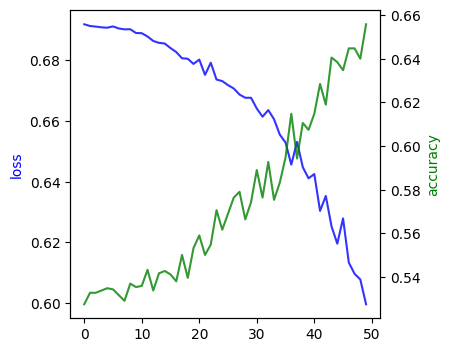

```python
plotRnnResults(history)
```

```python
lstm.evaluate(x_test_rnn_1, y_test_rnn_1)
```

```
2022-10-29 21:05:52.908482: I tensorflow/core/grappler/optimizers/custom_graph_optimizer_registry.cc:114] Plugin optimizer for device_type GPU is enabled.
2022-10-29 21:05:52.974252: I tensorflow/core/grappler/optimizers/custom_graph_optimizer_registry.cc:114] Plugin optimizer for device_type GPU is enabled.
2022-10-29 21:05:53.058933: I tensorflow/core/grappler/optimizers/custom_graph_optimizer_registry.cc:114] Plugin optimizer for device_type GPU is enabled.
```

```
[0.7654531598091125, 0.569444477558136]
```

```python
df_accuracy['lstm'] = pd.Series([history.history['accuracy'][-1], 0.5694], index=['train', 'test'])
print(df_accuracy)
```

```
          naive       rfr    rfr_mf  rfr_hypo  rfr_recur       gru    gru_mf  \
train  0.486996  0.619776  0.672783  0.579001   0.604759  0.527588  0.538623
test   0.500000  0.494908  0.507128  0.535642   0.521645  0.523100  0.534700

           lstm
train  0.655807
test   0.569400
```

LSTM appears to have smoother loss and accuracy changes accross epochs. Besides, LSTM achives around 13% higher training accuracy and 5% higher test accuracy than GRU with similar parameters. However, the test accuracy is still not significantly higher than the benchmark model's. Now let's add more features to the LSTM model training.

## LSTM with More Features

Hyperparameter turning has been done, details are summarized in the project report. Parameters tuned include batch_size in [16, 32, 64] and epochs in [10, 20, 30, 40, 50, 100]. In view of the training and testing sample size, which are 1903 and 432 respectively, larger batch size was not used. Besides, the training and testing accuracy did not seem to improve much with epochs larger than 100. Unlike GRU, whose training accuracy was capped at around 62%, LSTM achieved higher training accuracy of up to 88% with similar batch size and epoch settings. However, the testing accuracy for both models appeared comparable. In below section, the best-performing hyperparameters tried are used for model training.

```python
lstm = buildLstmModel(x_train_rnn_2.shape)
lstm.summary()
```

```
Model: "sequential_11"
_________________________________________________________________
 Layer (type)                Output Shape              Param #
=================================================================
 lstm_4 (LSTM)               (None, 60, 50)            12600

 lstm_5 (LSTM)               (None, 50)                20200

 dense_11 (Dense)            (None, 1)                 51

=================================================================
Total params: 32,851
Trainable params: 32,851
Non-trainable params: 0
_________________________________________________________________
```

```python
# Fit the model
history = lstm.fit(x_train_rnn_2, y_train_rnn_2, batch_size=64, epochs=50)
```

```
2022-10-29 21:17:26.512878: I tensorflow/core/grappler/optimizers/custom_graph_optimizer_registry.cc:114] Plugin optimizer for device_type GPU is enabled.
2022-10-29 21:17:26.668427: I tensorflow/core/grappler/optimizers/custom_graph_optimizer_registry.cc:114] Plugin optimizer for device_type GPU is enabled.
2022-10-29 21:17:26.767083: I tensorflow/core/grappler/optimizers/custom_graph_optimizer_registry.cc:114] Plugin optimizer for device_type GPU is enabled.
2022-10-29 21:17:26.935383: I tensorflow/core/grappler/optimizers/custom_graph_optimizer_registry.cc:114] Plugin optimizer for device_type GPU is enabled.
```

```
2022-10-29 21:17:27.110681: I tensorflow/core/grappler/optimizers/custom_graph_optimizer_registry.cc:114] Plugin optimizer for device_type GPU is enabled.
```

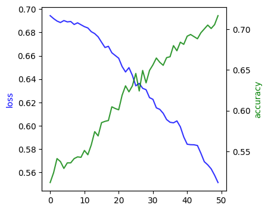

```python
plotRnnResults(history)
```

```python
lstm.evaluate(x_test_rnn_2, y_test_rnn_2)
```

```
2022-10-29 21:19:04.068204: I tensorflow/core/grappler/optimizers/custom_graph_optimizer_registry.cc:114] Plugin optimizer for device_type GPU is enabled.
2022-10-29 21:19:04.128857: I tensorflow/core/grappler/optimizers/custom_graph_optimizer_registry.cc:114] Plugin optimizer for device_type GPU is enabled.
2022-10-29 21:19:04.216908: I tensorflow/core/grappler/optimizers/custom_graph_optimizer_registry.cc:114] Plugin optimizer for device_type GPU is enabled.
```

```
[0.8514965176582336, 0.5486111044883728]
```

```python
df_accuracy['lstm_mf'] = pd.Series([history.history['accuracy'][-1], 0.5486], index=['train', 'test'])
print(df_accuracy)
```

```
          naive       rfr    rfr_mf  rfr_hypo  rfr_recur       gru    gru_mf  \
train  0.486996  0.619776  0.672783  0.579001   0.604759  0.527588  0.538623
test   0.500000  0.494908  0.507128  0.535642   0.521645  0.523100  0.534700

           lstm   lstm_mf
train  0.655807  0.716763
test   0.569400  0.548600
```

Let's see how LSTM performs for a 2-day ahead prediction.

```python
# Build and fit the model
lstm = buildLstmModel(x_train_rnn_3.shape)
history = lstm.fit(x_train_rnn_3, y_train_rnn_3, batch_size=64, epochs=50)
```

```
2022-10-29 21:25:20.918875: I tensorflow/core/grappler/optimizers/custom_graph_optimizer_registry.cc:114] Plugin optimizer for device_type GPU is enabled.
2022-10-29 21:25:21.068145: I tensorflow/core/grappler/optimizers/custom_graph_optimizer_registry.cc:114] Plugin optimizer for device_type GPU is enabled.
2022-10-29 21:25:21.167016: I tensorflow/core/grappler/optimizers/custom_graph_optimizer_registry.cc:114] Plugin optimizer for device_type GPU is enabled.
2022-10-29 21:25:21.326930: I tensorflow/core/grappler/optimizers/custom_graph_optimizer_registry.cc:114] Plugin optimizer for device_type GPU is enabled.
```

```
2022-10-29 21:25:21.501610: I tensorflow/core/grappler/optimizers/custom_graph_optimizer_registry.cc:114] Plugin optimizer for device_type GPU is enabled.
```

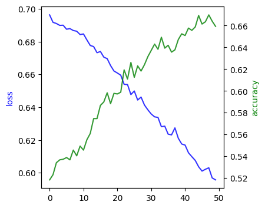

```python
plotRnnResults(history)
```

```python
lstm.evaluate(x_test_rnn_3, y_test_rnn_3)
```

```
2022-10-29 21:28:38.823621: I tensorflow/core/grappler/optimizers/custom_graph_optimizer_registry.cc:114] Plugin optimizer for device_type GPU is enabled.
2022-10-29 21:28:38.889346: I tensorflow/core/grappler/optimizers/custom_graph_optimizer_registry.cc:114] Plugin optimizer for device_type GPU is enabled.
2022-10-29 21:28:38.986843: I tensorflow/core/grappler/optimizers/custom_graph_optimizer_registry.cc:114] Plugin optimizer for device_type GPU is enabled.
```

```
[0.8509291410446167, 0.5150812268257141]
```

```python
# 2-day ahead prediction accuracy
df_accuracy_2d['lstm'] = pd.Series([history.history['accuracy'][-1], 0.5151], index=['train', 'test'])
print(df_accuracy_2d)
```

```
          naive       gru      lstm
train  0.502551  0.523134  0.659306
test   0.486708  0.501200  0.515100
```

LSTM achived 15% higher training accuracy and 3% highier test accuracy for 2-day ahead prediction compared to the benchmark. However, this imporement is not considered significant.

## Results and Conclusion

In this project, I used Random Forest, Gated Recurrent Unit(GRU) and Long Short Term Memory neural network(LSTM) along with time series stock data to build a classification model for predicting the direction of stock price movement for the next 1 day or 2 days, and benchmarked the prediction accuracy against the Naive Method. Some key observations:

- Prediction accuracy of machine learning models for this specific problem is not higher than 60%.
- Machine Learning models outperform the Naive Method by up to 7% higher test accuracy. However, this improvement is not significant compared to some of other machine learning classification use cases.
- Prediction accuracy for 1-day ahead is up to 5% higher than for 2-day ahead.
- LSTM which utilizes past sequence data appears to have the best performance among the models evaluated. However, longer timesteps do not significantly improve model performance.
- Models trained using multiple features tend to but not always have higher prediction accuracy than those trained using a single feature.

Why is the accuracy of ML models not high in this specific case? One possible reason is that crucial factors that affect stock price movement are not captured in the available dataset used for model training. To name a few -- overnight news, unexpected events, politics, market sentiments, or even some celebrity posting a tweet -- these factors may not be quantified into the training data and used for model training in the previous day. On the other hand, if a model can easily predict the direction of stock price movement with publicly available data at high accuracy, such model would be exploited in a real investment or trading strategy and make a plenty of money. Meanwhile, majority of market participants might seek to adopt the same model whereby market dynamics could change again, making the model’s superior performance no longer hold.

### Improvements

From data's perspective, adding and tracking additional metrics such as market events and events' impacts to the stock price, e.g. expected percentage contribution to the stock price change, impact factor on a scale of 0 to 10, etc, may be useful and likely to enable higher predictive power of machine learning models. Web scrapers can be used to retrieve market news and events for establishing such metrics. However, it may be challenging to restore and backfill these metrics for the past few decades and maintain such data as a private competitive edge. Alternative data sources that provide relevant information may also be explored. On the other hand, more technical indicators such as Bollinger Bands and standard deviation of stock price can be evaluated as additional features for any potential contribution to model performance.

From model training's perspective, if more time were given, some additional optimization can be done, such as cross-validation and further hyperparameter tuning. Besides, the models can be evaluated using more stock symbols to ensure consistency of model performance.